# Using Machine Learning Algorithms to Predict the Probability of a Heart Disease

Akash Sukhija (sukhija4@illinois.edu)

November 11, 2020

## Abstract

> Introduction: Gives a Brief Overview of the Project

> Methods : Discusses about the Data, Various Preprocessing Techniques, and the different Models under consideration

> Results : Exhibit the results of the models experimented with in the Methods section

## Introduction

Using Machine Learning Algorithms to Predict the Probability of a Heart Disease.

Heart Diseases are a major cause of deaths all around the globe. (Yes, it’s a Globe and not a Flat Surface) Millions of deaths can be avoided if the disease is found well in advance and treated upon to remove the blockages from the arteries. Finding an abnormality in the heart can be done via a procedure called Angiography. Angiography or Coronary Angiogram is a process where X-rays are used to study the condition of blood vessels in the arms, chest, or head. Any obstruction of the blood vessels is identified, recorded and reported to the consulting Cardiologist. The angiogram is performed by placing a catheter in an artery or vein to be reviewed. An iodine dye is injected into the artery, which allows an x-ray to view the exact site of any blockage or tear in an artery.

However, extracting an Angiogram using Angiography can be a highly intrusive and a highly expensive procedure. With this project I plan to introduce a tool that can help predict the presence of heart disease with minimal intrusion and a high accuracy rate. The tool will utilize data from heart patients such the patient’s age, sex, cholesterol levels and 11 other attributes that will help our tool learn better and make accurate predictions.

#### We’ll start by looking at the Data:

Data summary

| Name | hd |
| --- | --- |
| Number of rows | 920 |
| Number of columns | 15 |
| _______________________ |  |
| Column type frequency: |  |
| character | 2 |
| numeric | 13 |
| ________________________ |  |
| Group variables | None |

**Variable type: character**

| skim_variable | n_missing | complete_rate | min | max | empty | n_unique | whitespace |
| --- | --- | --- | --- | --- | --- | --- | --- |
| num | 0 | 1 | 2 | 2 | 0 | 5 | 0 |
| location | 0 | 1 | 2 | 2 | 0 | 4 | 0 |

**Variable type: numeric**

| skim_variable | n_missing | complete_rate | mean | sd | p0 | p25 | p50 | p75 | p100 | hist |
| --- | --- | --- | --- | --- | --- | --- | --- | --- | --- | --- |
| age | 0 | 1.00 | 53.51 | 9.42 | 28.0 | 47 | 54.0 | 60.0 | 77.0 | ▁▅▇▆▁ |
| sex | 0 | 1.00 | 0.79 | 0.41 | 0.0 | 1 | 1.0 | 1.0 | 1.0 | ▂▁▁▁▇ |
| cp | 0 | 1.00 | 3.25 | 0.93 | 1.0 | 3 | 4.0 | 4.0 | 4.0 | ▁▃▁▃▇ |
| trestbps | 59 | 0.94 | 132.13 | 19.07 | 0.0 | 120 | 130.0 | 140.0 | 200.0 | ▁▁▅▇▁ |
| chol | 30 | 0.97 | 199.13 | 110.78 | 0.0 | 175 | 223.0 | 268.0 | 603.0 | ▃▇▇▁▁ |
| fbs | 90 | 0.90 | 0.17 | 0.37 | 0.0 | 0 | 0.0 | 0.0 | 1.0 | ▇▁▁▁▂ |
| restecg | 2 | 1.00 | 0.60 | 0.81 | 0.0 | 0 | 0.0 | 1.0 | 2.0 | ▇▁▂▁▃ |
| thalach | 55 | 0.94 | 137.55 | 25.93 | 60.0 | 120 | 140.0 | 157.0 | 202.0 | ▁▃▇▇▂ |
| exang | 55 | 0.94 | 0.39 | 0.49 | 0.0 | 0 | 0.0 | 1.0 | 1.0 | ▇▁▁▁▅ |
| oldpeak | 62 | 0.93 | 0.88 | 1.09 | -2.6 | 0 | 0.5 | 1.5 | 6.2 | ▁▇▆▁▁ |
| slope | 309 | 0.66 | 1.77 | 0.62 | 1.0 | 1 | 2.0 | 2.0 | 3.0 | ▅▁▇▁▂ |
| ca | 611 | 0.34 | 0.68 | 0.94 | 0.0 | 0 | 0.0 | 1.0 | 3.0 | ▇▃▁▂▁ |
| thal | 486 | 0.47 | 5.09 | 1.92 | 3.0 | 3 | 6.0 | 7.0 | 7.0 | ▇▁▁▂▇ |

From the above ‘Skimming’ or a Brief Univariate/Single Attribute Analysis of Our Data, it has come to light that there are values in the Cholesterol Attribute that have Zero Values which can be assumed to be errors while collecting the data.

#### Inspecting the Zero Cholesterol Values by creating a Plot.

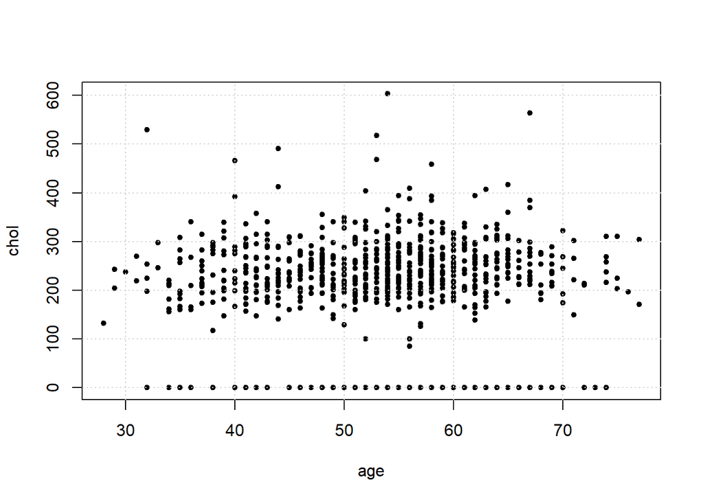

## Methods

### Data

The Data contains 14 attributes but many columns contain NAs which need to be to reduced for better predictions.

#### List of Attributes in the Dataset:

age, sex, cp, trestbps, chol, fbs,restecg, thalach, exang, oldpeak, slope,ca, thal, num( The Response Variable)

1. Cleaning the Data

Below is a Snippet of the Clean Data

```
## # A tibble: 740 x 12
##      age   sex    cp trestbps  chol   fbs restecg thalach exang oldpeak num
##    <dbl> <dbl> <dbl>    <dbl> <dbl> <dbl>   <dbl>   <dbl> <dbl>   <dbl> <chr>
##  1    63     1     1      145   233     1       2     150     0     2.3 v0
##  2    67     1     4      160   286     0       2     108     1     1.5 v2
##  3    67     1     4      120   229     0       2     129     1     2.6 v1
##  4    37     1     3      130   250     0       0     187     0     3.5 v0
##  5    41     0     2      130   204     0       2     172     0     1.4 v0
##  6    56     1     2      120   236     0       0     178     0     0.8 v0
##  7    62     0     4      140   268     0       2     160     0     3.6 v3
##  8    57     0     4      120   354     0       0     163     1     0.6 v0
##  9    63     1     4      130   254     0       2     147     0     1.4 v2
## 10    53     1     4      140   203     1       2     155     1     3.1 v1
## # ... with 730 more rows, and 1 more variable: location <chr>
```

2. Splitting the Data into Train and Testing Splits
3. Omitting The Zero Values from the Cholesterol Column
4. Feature Engineering (Converting Columns into Factors for Better Learning of the Algorithm)

A Snippet of the Columns after conversion.

```
## # A tibble: 531 x 12
##      age sex   cp    trestbps  chol fbs   restecg thalach exang oldpeak num
##    <dbl> <fct> <fct>    <dbl> <dbl> <fct> <fct>     <dbl> <fct>   <dbl> <fct>
##  1    53 1     4          120   246 0     0           116 1         0   v1
##  2    67 0     3          115   564 0     2           160 0         1.6 v0
##  3    65 1     4          110   248 0     2           158 0         0.6 v1
##  4    67 0     3          152   277 0     0           172 0         0   v0
##  5    47 1     3          108   243 0     0           152 0         0   v1
##  6    60 1     4          130   186 1     1           140 1         0.5 v1
##  7    65 0     3          140   417 1     2           157 0         0.8 v0
##  8    54 1     4          110   239 0     0           126 1         2.8 v3
##  9    38 1     3          138   175 0     0           173 0         0   v0
## 10    58 1     3          132   224 0     2           173 0         3.2 v3
## # ... with 521 more rows, and 1 more variable: location <fct>
```

5. Converting the Problem from a Multi-Class Classification to a Binary Classification problem. The response variable (or the variable that needs to be predicted) in our dataset contains a factor with 5 levels (v0, v1, v2, v3 and v4). The Variable v0 represents NO heart disease and other variables represent presence of heart disease. Converting v0 to ‘0’ and others to ‘1’. This is done to simplify the problem, whether a patient has heart disease or not.

[output not shown]

Applying the Same Transformations on the Test Split as done earlier on the Train Split

### Modeling

#### Three Models are Trained on the Train Dataset

#### 1. Decision Tree Classifier

Code : hd_tree_mod = train(form = num~., data = trn, method = “rpart”, trControl = cv_10, tuneLength = 15 )

Results with Cross Validation:

```
##            cp  Accuracy     Kappa AccuracySD    KappaSD
## 1  0.00000000 0.7645614 0.5288515 0.04728648 0.09561768
## 2  0.03681319 0.7626316 0.5251108 0.05627396 0.11270725
## 3  0.07362637 0.7626316 0.5251108 0.05627396 0.11270725
## 4  0.11043956 0.7626316 0.5251108 0.05627396 0.11270725
## 5  0.14725275 0.7626316 0.5251108 0.05627396 0.11270725
## 6  0.18406593 0.7626316 0.5251108 0.05627396 0.11270725
## 7  0.22087912 0.7626316 0.5251108 0.05627396 0.11270725
## 8  0.25769231 0.7626316 0.5251108 0.05627396 0.11270725
## 9  0.29450549 0.7626316 0.5251108 0.05627396 0.11270725
## 10 0.33131868 0.7626316 0.5251108 0.05627396 0.11270725
## 11 0.36813187 0.7626316 0.5251108 0.05627396 0.11270725
## 12 0.40494505 0.7626316 0.5251108 0.05627396 0.11270725
## 13 0.44175824 0.7626316 0.5251108 0.05627396 0.11270725
## 14 0.47857143 0.7626316 0.5251108 0.05627396 0.11270725
## 15 0.51538462 0.6310526 0.2506644 0.11036789 0.23465977
```

#### 2. Gradient Boosting Machine Classifier

Code: hd_gbm_mod = train(form = num~., data = trn, method = “gbm”, trControl = cv_10, verbose = FALSE )

Results with Cross Validation:

```
##   shrinkage interaction.depth n.minobsinnode n.trees  Accuracy     Kappa
## 1       0.1                 1             10      50 0.8004511 0.6004215
## 4       0.1                 2             10      50 0.8004511 0.6004138
## 7       0.1                 3             10      50 0.8005263 0.6009828
## 2       0.1                 1             10     100 0.8004511 0.6004230
## 5       0.1                 2             10     100 0.8023308 0.6044000
## 8       0.1                 3             10     100 0.7816792 0.5633161
## 3       0.1                 1             10     150 0.8079950 0.6154519
## 6       0.1                 2             10     150 0.8023810 0.6044250
## 9       0.1                 3             10     150 0.7873183 0.5746659
##   AccuracySD    KappaSD
## 1 0.05204536 0.10433463
## 4 0.05832015 0.11646244
## 7 0.06015216 0.11990886
## 2 0.04490210 0.08973839
## 5 0.05762045 0.11506109
## 8 0.06711353 0.13402933
## 3 0.04703989 0.09388214
## 6 0.05851983 0.11685328
## 9 0.05617641 0.11216117
```

#### 3. Naive Bayes Classifier

Code : hd_nb_mob = train(form = num~., data = trn, method = “naive_bayes”, trControl = cv_10 )

Results with Cross Validation:

```
##   usekernel laplace adjust  Accuracy     Kappa AccuracySD    KappaSD
## 1     FALSE       0      1 0.8003008 0.6002842 0.03883918 0.07738626
## 2      TRUE       0      1 0.7984712 0.5959441 0.03121702 0.06306227
```

## Results

Calculating the Accuracy of All the Models using the Test Data

```
## [1] "The Accuracy of Decision Tree Classifier is 0.746154:"
```

```
## [1] "The Accuracy of Gradient Boosting Machine Classifier is 0.784615"
```

```
## [1] "The Accuracy of Naive Bayes Classifier is 0.792308"
```

## Appendix

Source : https://www.medicoverhospitals.in/difference-between-angiography-and-angioplasty

#### Data(Attribute) Definitions:

3 age: age in years 4 sex: sex (1 = male; 0 = female) 9 cp: chest pain type – Value 1: typical angina – Value 2: atypical angina – Value 3: non-anginal pain – Value 4: asymptomatic 10 trestbps: resting blood pressure (in mm Hg on admission to the hospital) 12 chol: serum cholestoral in mg/dl 16 fbs: (fasting blood sugar > 120 mg/dl) (1 = true; 0 = false) 19 restecg: resting electrocardiographic results – Value 0: normal – Value 1: having ST-T wave abnormality (T wave inversions and/or ST elevation or depression of > 0.05 mV) – Value 2: showing probable or definite left ventricular hypertrophy by Estes’ criteria

32 thalach: maximum heart rate achieved

38 exang: exercise induced angina (1 = yes; 0 = no)

40 oldpeak = ST depression induced by exercise relative to rest 41 slope: the slope of the peak exercise ST segment – Value 1: upsloping – Value 2: flat – Value 3: downsloping

44 ca: number of major vessels (0-3) colored by flourosopy

51 thal: 3 = normal; 6 = fixed defect; 7 = reversable defect

58 num: diagnosis of heart disease (angiographic disease status) – Value 0: < 50% diameter narrowing – Value 1: > 50% diameter narrowing (in any major vessel: attributes 59 through 68 are vessels)

Definition Source: https://archive.ics.uci.edu/ml/datasets/Heart+Disease